# IODS course project

mjelbart

# About the project

I’m well. I expect to learn about using R for data science. I heard about this course from a friend.

**Github repo:** [link](https://github.com/mjelbart/IODS-project/) **Course diary:** [link](https://mjelbart.github.io/IODS-project/)

# Chapter 2: Regression and model validation

- Describe your work and results clearly.
- Assume the reader has an introductory course level understanding of writing and reading R code as well as statistical methods.
- Assume the reader has no previous knowledge of your data or the more advanced methods you are using.

### Analysis: Section 1

I started by checking my working directory

```r
getwd()
```

```
## [1] "C:/Users/OMISTAJA/Documents/IODS-project"
```

Read in the data which includes headers and uses comma as a separator

```r
students2014 <- read.table("C:/Users/OMISTAJA/Documents/IODS-project/data/learning2014.txt", header=TRUE, sep=",")
```

Explored the structure of the data to show that it has 166 obs. of 7 variables

```r
str(students2014)
```

```
## 'data.frame':    166 obs. of  7 variables:
##  $ gender  : Factor w/ 2 levels "F","M": 1 2 1 2 2 1 2 1 2 1 ...
##  $ age     : int  53 55 49 53 49 38 50 37 37 42 ...
##  $ attitude: num  3.7 3.1 2.5 3.5 3.7 3.8 3.5 2.9 3.8 2.1 ...
##  $ deep    : num  3.58 2.92 3.5 3.5 3.67 ...
##  $ stra    : num  3.38 2.75 3.62 3.12 3.62 ...
##  $ surf    : num  2.58 3.17 2.25 2.25 2.83 ...
##  $ points  : int  25 12 24 10 22 21 21 31 24 26 ...
```

Explored the structure of the data using dim(), showing that it has 166 rows and 7 columns

```r
dim(students2014)
```

```
## [1] 166   7
```

**A Brief Description of the Dataset:** This data set is from the international survey of Approaches to Learning. The central measure in this study were questions related to Deep, Surface and Strategic learning answered on a Likert scale. There were 8-12 questions for each category. Combination variables were created from these which were then scaled to the original scales by taking the mean. Data is also included for Age, attitute toward statistics, exam points, and gender. Excluded data: observations with exam points of zero were excluded.

### Analysis: Section 2

A graphical overview of the data using ggplot2 and GGally to make an advanced plot matrix

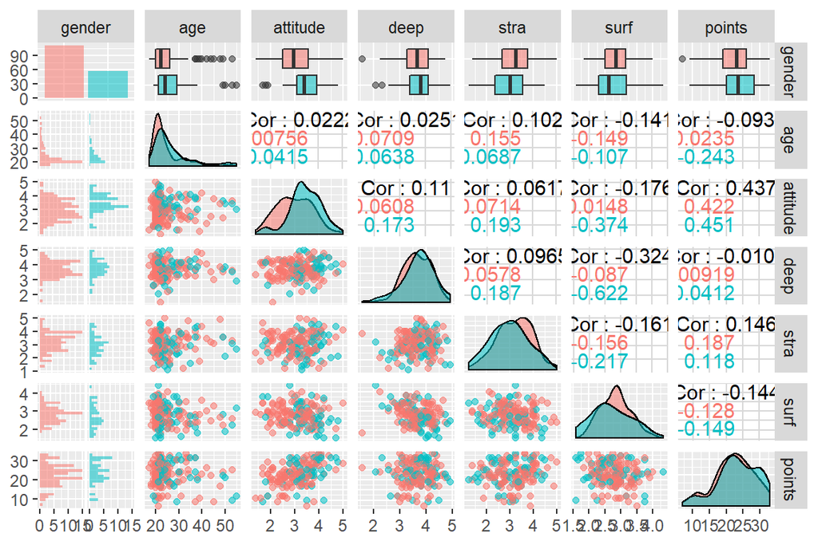

```r
library(ggplot2)
library(GGally)
ggpairs(students2014, mapping = aes(col = gender, alpha = 0.3), lower = list(combo = wrap("facethist", bins = 20)))
```

A summary of the variables in the data

```r
summary(students2014)
```

```
##  gender       age           attitude          deep            stra
##  F:110   Min.   :17.00   Min.   :1.400   Min.   :1.583   Min.   :1.250
##  M: 56   1st Qu.:21.00   1st Qu.:2.600   1st Qu.:3.333   1st Qu.:2.625
##          Median :22.00   Median :3.200   Median :3.667   Median :3.188
##          Mean   :25.51   Mean   :3.143   Mean   :3.680   Mean   :3.121
##          3rd Qu.:27.00   3rd Qu.:3.700   3rd Qu.:4.083   3rd Qu.:3.625
##          Max.   :55.00   Max.   :5.000   Max.   :4.917   Max.   :5.000
##       surf           points
##  Min.   :1.583   Min.   : 7.00
##  1st Qu.:2.417   1st Qu.:19.00
##  Median :2.833   Median :23.00
##  Mean   :2.787   Mean   :22.72
##  3rd Qu.:3.167   3rd Qu.:27.75
##  Max.   :4.333   Max.   :33.00
```

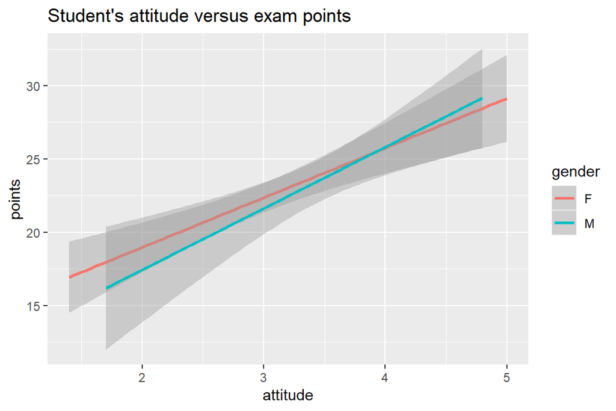

```r
gender_comparison <- ggplot(students2014, aes(x = attitude, y = points, col = gender, labs(title="Student's attitude versus exam points")))
gender_comparison + ggtitle("Student's attitude versus exam points") + geom_smooth(method = "lm")
```

### Analysis: Section 3 & 4

Three explanatory variables (attitude, strategic learning, surface learning) fitted to a regression model with exam points as the target (dependent) variable:

```r
summary(lm(points ~ attitude + stra + surf, data = students2014))
```

```
##
## Call:
## lm(formula = points ~ attitude + stra + surf, data = students2014)
##
## Residuals:
##      Min       1Q   Median       3Q      Max
## -17.1550  -3.4346   0.5156   3.6401  10.8952
##
## Coefficients:
##             Estimate Std. Error t value Pr(>|t|)
## (Intercept)  11.0171     3.6837   2.991  0.00322 **
## attitude      3.3952     0.5741   5.913 1.93e-08 ***
## stra          0.8531     0.5416   1.575  0.11716
## surf         -0.5861     0.8014  -0.731  0.46563
## ---
## Signif. codes:  0 '***' 0.001 '**' 0.01 '*' 0.05 '.' 0.1 ' ' 1
##
## Residual standard error: 5.296 on 162 degrees of freedom
## Multiple R-squared:  0.2074, Adjusted R-squared:  0.1927
## F-statistic: 14.13 on 3 and 162 DF,  p-value: 3.156e-08
```

Interpretation of the results: Attitude is the only statistically significant predictor of exam points with a t-test p value, Pr(>|t|), less than 0.001. The better people’s attitude towards learning was the better they tended to do in the exam.

The same model with the statistically insignificant explanatory variables removed:

```r
final_model <- lm(points ~ attitude, data = students2014)
summary("final_model")
```

[output not shown]

### Analysis: Section 5

Diagnostic plots: Residuals vs Fitted values, Normal QQ-plot and Residuals vs Leverage.

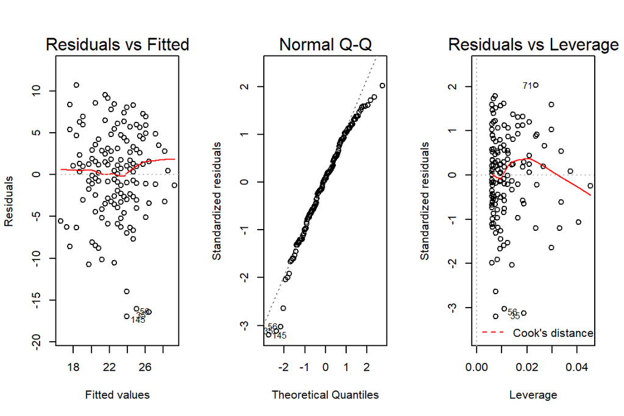

```r
par(mfrow = c(1,3))
plot(final_model, which = c(1,2,5))
```

The assumptions of a linear regression model are: * Errors have constant variance σ^2 * Errors normally distributed * Errors not correlated * The size of a given error does not depend on the explanatory variables

The variance of the errors are reasonable constant, this is shown by the values in the Residuals vs Fitted values plot being randomly scattered. The errors are normally distributed, this is shown by most of the values staying along the regression line in the QQ plot. No one value should have a leverage and while the Residuals vs Leverage plot shows outliers with higher leverage the x-axis is very short so the graphic makes it seem like a bigger problem than it is.

# Chapter 3: Logistic Regression

## 2. The dataset

### A brief description of the dataset:

The dataset regards student achievement in secondary education of two Portuguese schools, collected by using school reports and questionnaires. The data attributes include student grades, demographic, social and school related features. More on the two data sets (from which the alc dataset is composed) can be found at https://archive.ics.uci.edu/ml/datasets/Student+Performance

Data wrangling notes

- Data from students of two subjects have been joined.
- The variables not used for correlating the two data have been combined by averaging.
- The variable ‘alc_use’ (alcohol use) is the average of ‘Dalc’ and ‘Walc’ (Daily alcohol consumption and Weekly alcohol consumption).
- The variable ‘high_use’ is TRUE if ‘alc_use’ is higher than 2 and FALSE otherwise.

See the variables (column names) listed below:

```r
# Read the joined student alcohol consumption data into R
alc <- read.table("data/alc.txt", header = TRUE, sep=",")

# Print out the names of the variables in the data
colnames(alc)
```

```
##  [1] "school"     "sex"        "age"        "address"    "famsize"
##  [6] "Pstatus"    "Medu"       "Fedu"       "Mjob"       "Fjob"
## [11] "reason"     "nursery"    "internet"   "guardian"   "traveltime"
## [16] "studytime"  "failures"   "schoolsup"  "famsup"     "paid"
## [21] "activities" "higher"     "romantic"   "famrel"     "freetime"
## [26] "goout"      "Dalc"       "Walc"       "health"     "absences"
## [31] "G1"         "G2"         "G3"         "alc_use"    "high_use"
```

```r
str(alc)
```

```
## 'data.frame':    382 obs. of  35 variables:
##  $ school    : Factor w/ 2 levels "GP","MS": 1 1 1 1 1 1 1 1 1 1 ...
##  $ sex       : Factor w/ 2 levels "F","M": 1 1 1 1 1 2 2 1 2 2 ...
##  $ age       : int  18 17 15 15 16 16 16 17 15 15 ...
##  $ address   : Factor w/ 2 levels "R","U": 2 2 2 2 2 2 2 2 2 2 ...
##  $ famsize   : Factor w/ 2 levels "GT3","LE3": 1 1 2 1 1 2 2 1 2 1 ...
##  $ Pstatus   : Factor w/ 2 levels "A","T": 1 2 2 2 2 2 2 1 1 2 ...
##  $ Medu      : int  4 1 1 4 3 4 2 4 3 3 ...
##  $ Fedu      : int  4 1 1 2 3 3 2 4 2 4 ...
##  $ Mjob      : Factor w/ 5 levels "at_home","health",..: 1 1 1 2 3 4 3 3 4 3 ...
##  $ Fjob      : Factor w/ 5 levels "at_home","health",..: 5 3 3 4 3 3 3 5 3 3 ...
##  $ reason    : Factor w/ 4 levels "course","home",..: 1 1 3 2 2 4 2 2 2 2 ...
##  $ nursery   : Factor w/ 2 levels "no","yes": 2 1 2 2 2 2 2 2 2 2 ...
##  $ internet  : Factor w/ 2 levels "no","yes": 1 2 2 2 1 2 2 1 2 2 ...
##  $ guardian  : Factor w/ 3 levels "father","mother",..: 2 1 2 2 1 2 2 2 2 2 ...
```

[output cut: 21 more lines]

## 3. In order to study the relationships between high/low alcohol consumption and some of the other variables in the data I will choose four interesting variables and present my hypotheses about their relationship with alcohol consumption.

### My hypotheses

1. Males: Alcohol useage will be higher for males.
2. Free time: Alcohol usage will be higher for students with more free time.
3. Failures: Alcohol usage will be higher for students with more failures.
4. Absences: Students with higher alcohol usage will have more absences.

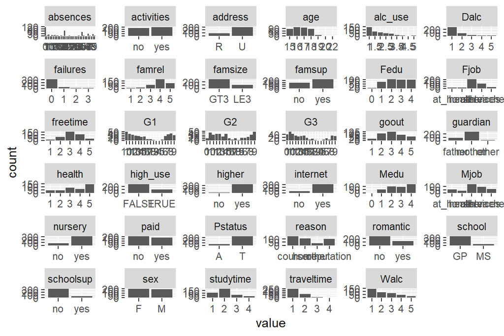

```r
library(tidyr); library(dplyr); library(ggplot2)
gather(alc) %>% ggplot(aes(value)) + facet_wrap("key", scales = "free") + geom_bar()
```

### Comments on my findings and comparisons of the results of my exploration to my previously stated hypotheses.

```r
model <- glm(high_use ~ sex + romantic + failures + absences, data = alc, family = "binomial")

model
```

```
##
## Call:  glm(formula = high_use ~ sex + romantic + failures + absences,
##     family = "binomial", data = alc)
##
## Coefficients:
## (Intercept)         sexM  romanticyes     failures     absences
##     -1.8769       0.9757      -0.2805       0.4142       0.0752
##
## Degrees of Freedom: 381 Total (i.e. Null);  377 Residual
## Null Deviance:       462.2
## Residual Deviance: 417.5     AIC: 427.5
```

### Presentation and interpretation of a summary of the fitted model.

```r
summary(model)
```

```
##
## Call:
## glm(formula = high_use ~ sex + romantic + failures + absences,
##     family = "binomial", data = alc)
##
## Deviance Residuals:
##     Min       1Q   Median       3Q      Max
## -2.6507  -0.8256  -0.6131   1.0339   2.1292
##
## Coefficients:
##             Estimate Std. Error z value Pr(>|z|)
## (Intercept)  -1.8769     0.2381  -7.882 3.23e-15 ***
## sexM          0.9757     0.2451   3.980 6.88e-05 ***
## romanticyes  -0.2806     0.2655  -1.057  0.29063
## failures      0.4142     0.1511   2.741  0.00613 **
## absences      0.0752     0.0182   4.132 3.59e-05 ***
## ---
## Signif. codes:  0 '***' 0.001 '**' 0.01 '*' 0.05 '.' 0.1 ' ' 1
##
## (Dispersion parameter for binomial family taken to be 1)
##
##     Null deviance: 462.21  on 381  degrees of freedom
## Residual deviance: 417.51  on 377  degrees of freedom
## AIC: 427.51
##
## Number of Fisher Scoring iterations: 4
```

### Presentation and interpretation of the coefficients of the model as odds ratios and confidence intervals for them.

SexM, Failures and Absences all have an odds ratio over 1. This indicates that each of them are positively associated with alcohol use. Students with high alcohol use were more often male than female, failed more those with low alcohol use, and were absent more often than student with low alcohol use.

```r
oddsratios <- coef(model) %>% exp

confidenceintervals <- confint(model) %>% exp
cbind(oddsratios, confidenceintervals)
```

```
##             oddsratios      2.5 %    97.5 %
## (Intercept)  0.1530655 0.09415327 0.2400305
## sexM         2.6531230 1.65102057 4.3248387
## romanticyes  0.7553706 0.44426237 1.2613520
## failures     1.5131929 1.12471665 2.0427535
## absences     1.0781046 1.04265670 1.1194724
```

### Using these explore the predictive power of you model.

“When you have a linear model, you can make predictions. A very basic question is, of course, how well does our model actually predict the target variable.”

```r
# predict() the probability of high_use and add the predicted probabilities to the 'alc' data set
probabilities <- predict(model, type = "response")
alc <- mutate(alc, probability = probabilities)

# use the probabilities to make a prediction of high_use
alc <- mutate(alc, prediction = "change me!")

# use the probabilities to make a prediction of high_use. Mutate the data again: add a column 'prediction' which is true if the value of 'probability' is greater than 0.5.
alc <- mutate(alc, prediction = probabilities > 0.5)

# see the last ten original classes, predicted probabilities, and class predictions
select(alc, failures, absences, sex, high_use, probability, prediction) %>% tail(10)
```

```
##     failures absences sex high_use probability prediction
## 373        1        0   M    FALSE   0.3806170      FALSE
## 374        1       14   M     TRUE   0.6378242       TRUE
## 375        0        2   F    FALSE   0.1510383      FALSE
## 376        0        7   F    FALSE   0.1636928      FALSE
## 377        1        0   F    FALSE   0.1880597      FALSE
## 378        0        0   F    FALSE   0.1327465      FALSE
## 379        1        0   F    FALSE   0.1880597      FALSE
## 380        1        0   F    FALSE   0.1880597      FALSE
## 381        0        3   M     TRUE   0.3372578      FALSE
## 382        0        0   M     TRUE   0.2888138      FALSE
```

### Provide a 2x2 cross tabulation of predictions versus the actual values and optionally display a graphic visualizing both the actual values and the predictions.

```r
# tabulate the target variable versus the predictions. Use table() to create a cross table of the columns 'high_use' versus 'prediction' in alc. This is sometimes called a 'confusion matrix`.
table(high_use = alc$high_use, prediction = alc$prediction)
```

```
##         prediction
## high_use FALSE TRUE
##    FALSE   257   13
##    TRUE     84   28
```

```r
table(high_use = alc$high_use, prediction = alc$prediction) %>% prop.table() %>% addmargins()
```

```
##         prediction
## high_use      FALSE       TRUE        Sum
##    FALSE 0.67277487 0.03403141 0.70680628
##    TRUE  0.21989529 0.07329843 0.29319372
##    Sum   0.89267016 0.10732984 1.00000000
```

### Computation of the total proportion of inaccurately classified individuals (= the training error) and comments on all the results.

The proportion of inaccurately classified observations can be obtained by a loss function.

## 7. Bonus: Perform 10-fold cross-validation on your model. Does your model have better test set performance (smaller prediction error using 10-fold cross-validation) compared to the model introduced in DataCamp (which had about 0.26 error). Could you find such a model? (0-2 points to compensate any loss of points from the above exercises)

```r
# define a loss function (average prediction error)
loss_func <- function(class, prob) {
  n_wrong <- abs(class - prob) > 0.5
  mean(n_wrong)
}

# compute the average number of wrong predictions in the (training) data
loss_func(alc$high_use, alc$probability)
```

```
## [1] 0.2539267
```

```r
library(boot)
cv <- cv.glm(data = alc, cost = loss_func, glmfit = model, K = 10)
cv$delta[1]
```

```
## [1] 0.2643979
```